# Support Vector Machines

```r
#Cross-Validation -Find Best Model for prediction
tune.out<- tune(svm,y~.,data=dataframe,kernal="linear",ranges=list(cost=c(0.001,0.01,0.1,1,5,10,100)))
bestmodel=tune.out$best.model
summary(bestmodel)
```

```
##
## Call:
## best.tune(method = svm, train.x = y ~ ., data = dataframe, ranges = list(cost = c(0.001,
##     0.01, 0.1, 1, 5, 10, 100)), kernal = "linear")
##
##
## Parameters:
##    SVM-Type:  C-classification
##  SVM-Kernel:  radial
##        cost:  1
##       gamma:  0.5
##
## Number of Support Vectors:  15
##
##  ( 7 8 )
##
##
## Number of Classes:  2
##
## Levels:
##  -1 1
```

```r
##----------------------Let's focus on Predicting the Function ---

## Generate Test data
xtest = matrix(rnorm(40),ncol=2)
ytest = sample(c(-1,1),20,rep=TRUE)
xtest[ytest==1,]<- xtest[ytest==1,]+1

testdf<-data.frame(x=xtest,y=as.factor(ytest))
testdf
```

```
##            x.1         x.2  y
## 1  -1.12490028 -0.70278946 -1
## 2  -0.87430362  0.29986416 -1
## 3   1.04386162  2.14946968  1
## 4  -0.58397514 -0.30164149 -1
## 5   0.17670142  0.45266065  1
## 6   0.11059280 -0.38540415 -1
## 7   0.36472778  0.27637203 -1
## 8   0.05370100  0.15186081 -1
## 9   2.36867235  0.56861921  1
## 10  0.61954276 -0.87050006  1
## 11 -0.70632036  0.07633326 -1
## 12  1.96687656  0.76964405  1
## 13 -0.71016648  0.31746484 -1
## 14 -0.05917365 -1.59268440 -1
## 15 -0.23094342 -0.18194062 -1
## 16  1.69200045  2.75614174  1
## 17  2.35682290  1.11394932  1
## 18  2.78872284  0.70783492  1
## 19  1.41071582  2.75409316  1
## 20 -2.18785470  1.80958455 -1
```

```r
#Predict testdata(i.e. testdf ) based on bestmodel

ypred=predict(bestmodel,testdf)
ypred
```

```
##  1  2  3  4  5  6  7  8  9 10 11 12 13 14 15 16 17 18 19 20
## -1 -1  1 -1  1 -1  1 -1  1 -1 -1  1 -1 -1 -1  1  1  1  1  1
## Levels: -1 1
```

```r
table(pred=ypred,truth=testdf$y)
```

```
##     truth
## pred -1 1
##   -1  9 1
##   1   2 8
```

```r
# look only at agreement vs. non-agreement
# construct a vector of TRUE/FALSE indicating correct/incorrect predictions
agreement <- ypred == testdf$y
table(agreement)
```

```
## agreement
## FALSE  TRUE
##     3    17
```

```r
prop.table(table(agreement))
```

```
## agreement
## FALSE  TRUE
##  0.15  0.85
```

```r
##-------------- Improving model performance -----

classifier_rbf <- ksvm(y ~ ., data = testdf, kernel = "rbfdot")
predictions_rbf <- predict(classifier_rbf, testdf)
predictions_rbf
```

```
##  [1] -1 -1 1  -1 -1 -1 -1 -1 1  -1 -1 1  -1 -1 -1 1  1  1  1  -1
## Levels: -1 1
```

```r
agreement_rbf <- predictions_rbf == testdf$y
table(agreement_rbf)
```

```
## agreement_rbf
## FALSE  TRUE
##     2    18
```

```r
prop.table(table(agreement_rbf))
```

```
## agreement_rbf
## FALSE  TRUE
##   0.1   0.9
```

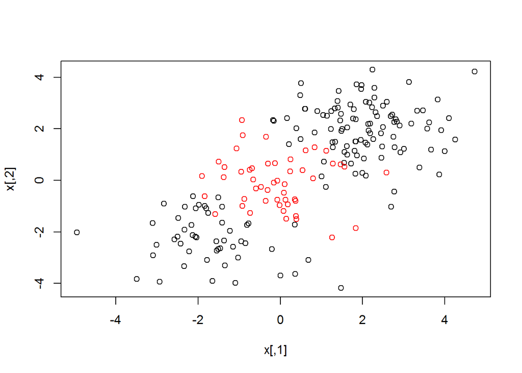

```r
####-------------------------- RADIAL KERNAL ( play with gamma and cost)  ------------------

# -----------Generate random Data----------

set.seed(33)
x<-matrix(rnorm(400),ncol=2)
x[1:100,]=x[1:100,]+2
x[101:150,]=x[101:150,]-2

y=c(rep(1,150),rep(2,50))
dat= data.frame(x=x,y=as.factor(y))

plot(x,col=y)
```

```r
# ----------- Training Model on data --------

train = sample(200,100)
train
```

```
##   [1]  61   1 130  56  43  20 158 160  68 122 100  26  55  74  22   3 116
##  [18] 188 174  91 121 153  23 187 142 192   4 185 127  67 155 157 179 125
##  [35]  69 108 200 106 133  49 171  87 135  11  18  76  57  95 190  77  38
##  [52]  72 129 169 175 162  80 196  60  30 177  92  35 176 152   7 126 134
##  [69]  28 199 128 191 173   2  34  58 165 167  86  54 181 145  24  16 156
##  [86]  10  66 112 103  78  31  90 111 123 184  65  53 117 150  89
```

```r
svmfit1<-svm(y~.,data=dat[train,],kernal="radial",gamma=1,cost=100000)
svmfit1
```

```
##
## Call:
## svm(formula = y ~ ., data = dat[train, ], kernal = "radial",
##     gamma = 1, cost = 1e+05)
##
##
## Parameters:
##    SVM-Type:  C-classification
##  SVM-Kernel:  radial
##        cost:  1e+05
##       gamma:  1
##
## Number of Support Vectors:  15
```

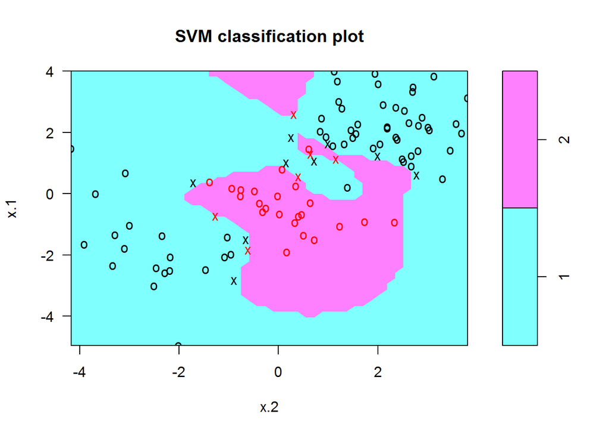

```r
plot(svmfit1,dat[train,])
```

```r
#------------- Cross Validation to set best choice of gamma and cost

tune.out= tune(svm,y~.,data=dat[train,],kernal="radial",ranges=list(cost=c(0.1,10,100,1000)),gamma=c(0.5,1,2,3,4))
summary(tune.out)
```

```
##
## Parameter tuning of 'svm':
##
## - sampling method: 10-fold cross validation
##
## - best parameters:
##  cost
##    10
##
## - best performance: 0.12
##
## - Detailed performance results:
##    cost error dispersion
## 1 1e-01  0.19 0.15951315
## 2 1e+01  0.12 0.07888106
## 3 1e+02  0.14 0.10749677
## 4 1e+03  0.17 0.10593499
```

```r
bestmodel1<-tune.out$best.model
bestmodel1
```

```
##
## Call:
## best.tune(method = svm, train.x = y ~ ., data = dat[train, ],
##     ranges = list(cost = c(0.1, 10, 100, 1000)), kernal = "radial",
##     gamma = c(0.5, 1, 2, 3, 4))
##
##
## Parameters:
##    SVM-Type:  C-classification
##  SVM-Kernel:  radial
##        cost:  10
##       gamma:  0.5 1 2 3 4
##
## Number of Support Vectors:  23
```

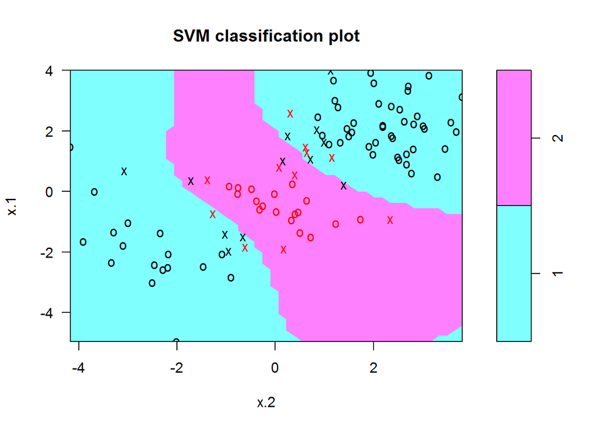

```r
plot(bestmodel1,dat[train,])
```

```r
test=-train
train
```

```
##   [1]  61   1 130  56  43  20 158 160  68 122 100  26  55  74  22   3 116
##  [18] 188 174  91 121 153  23 187 142 192   4 185 127  67 155 157 179 125
##  [35]  69 108 200 106 133  49 171  87 135  11  18  76  57  95 190  77  38
##  [52]  72 129 169 175 162  80 196  60  30 177  92  35 176 152   7 126 134
##  [69]  28 199 128 191 173   2  34  58 165 167  86  54 181 145  24  16 156
##  [86]  10  66 112 103  78  31  90 111 123 184  65  53 117 150  89
```

```r
 #  Prediction Error Comparison between Linear Regression and SVM  #


# Plot the data
plot(svm.data, pch=16)

# Create a linear regression model
lr_model <- lm(Y ~ X, svm.data)

# Add the fitted line
abline(lr_model)

# make a prediction for each X
predictedY <- predict(lr_model, svm.data)

# display the predictions
points(svm.data$X, predictedY, col = "blue", pch=4)

# Function to find the Error
rmse <- function(error)
{
  sqrt(mean(error^2))
}
error <- lr_model$residuals         # same as data$Y - predictedY
predictionRMSE <- rmse(error)
predictionRMSE
```

```
## [1] 5.703778
```

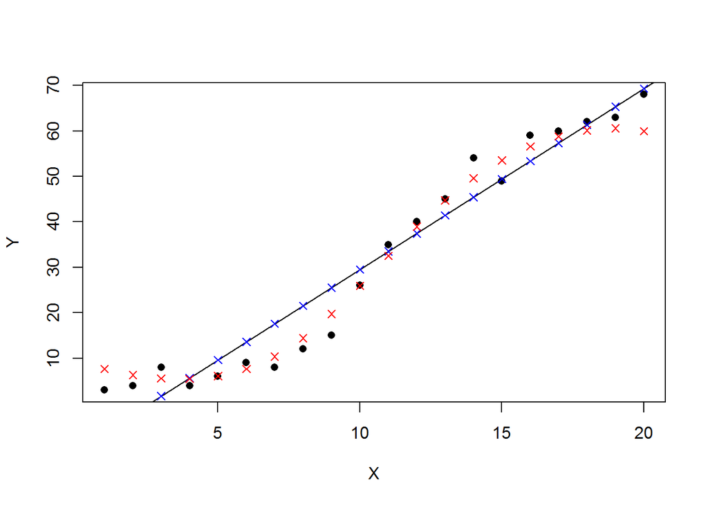

```r
                            # Support Vector Machine(Finding root mean square error)



# Create Support Vector Model
svm_model <- svm(Y ~ X , svm.data)

# make a prediction for each X
predictedY1 <- predict(svm_model, svm.data)

# display the predictions
points(svm.data$X, predictedY1, col = "red", pch=4)
```

```r
# Function to find the Error
error <- svm.data$Y - predictedY1
svrPredictionRMSE <- rmse(error)

tuneResult <- tune(svm, Y ~ X,  data = svm.data,ranges = list(epsilon = seq(0,1,0.1), cost = 2^(2:9)))
print(tuneResult)
```

```
##
## Parameter tuning of 'svm':
##
## - sampling method: 10-fold cross validation
##
## - best parameters:
##  epsilon cost
##        0  128
##
## - best performance: 8.702864
```

```r
svrPredictionRMSE
```

```
## [1] 3.157061
```

# Assingment

- Go to the [UC Irvine Machine Learning Repository](https://archive.ics.uci.edu/ml/) and find a dataset for supervised classification. Every student MUST use a different dataset so you MUST get approved for which you can going to use. This can be the same dataset you used for the unsupervised clustering as long as the data has some labeled data.
- Classify your data using Support Vector Machines. You can use any method/package for SVMs. Answer the following questions:
  - How well does the classifier perform?
  - Try different kernels. How do they effect its performce?
  - What might improve its performce?

# Resources

- [What are Kernels in Machine Learning and SVM?](https://www.quora.com/What-are-Kernels-in-Machine-Learning-and-SVM/answer/Nikhil-Garg)
- [Computing and visualizing LDA in R](https://tgmstat.wordpress.com/2014/01/15/computing-and-visualizing-lda-in-r/)
- [Computing and visualizing LDA in R](http://www.r-bloggers.com/computing-and-visualizing-lda-in-r/)